# R Notebook Create Reference matrix

```r
head(ussc)
```

|  | Gene | Marker | StemCell | NPC | Neuron | Astrocyte | OPC | Oligo | RG | Endothelial | Pericyte | Epithelial | Microglia |
| --- | --- | --- | --- | --- | --- | --- | --- | --- | --- | --- | --- | --- | --- |
| 1 | AQP4 | AQP4 | 0.0000000000 | NA | 0.001098026 | 0.000297278 | NA | NA | 4.899336e-06 | NA | NA | NA | NA |
| 2 | CD24 | CD24 | 1.4580551500 | NA | 1.491141100 | 0.509057320 | NA | NA | 8.207370e-01 | NA | NA | NA | NA |
| 3 | CD44 | CD44 | 0.0066162710 | NA | 0.002827613 | 0.064296065 | NA | NA | 1.233590e-02 | NA | NA | NA | NA |
| 4 | CXCR4 | CD184 | 0.1303124500 | NA | 0.181284290 | 0.280667010 | NA | NA | 3.096203e-01 | NA | NA | NA | NA |
| 5 | Fut4/ssea1 | CD15 | 0.0000000000 | NA | 0.000000000 | 0.000000000 | NA | NA | 9.904528e-05 | NA | NA | NA | NA |
| 6 | HepaCam | HEPACAM | 0.0004587798 | NA | 0.003605835 | 0.000204265 | NA | NA | 1.663370e-05 | NA | NA | NA | NA |

```r
head(mbo.47)
```

|  | Annotation | Marker | StemCell | NPC | Neuron | Astrocyte | OPC | Oligo | RG | Endothelial | Pericyte | Edpendymal | Microglial |
| --- | --- | --- | --- | --- | --- | --- | --- | --- | --- | --- | --- | --- | --- |
| 1 | Aqp4 | AQP4 | NA | 0.000000e+00 | 0.001962990 | 0.210211065 | NA | 0.000000000 | 0.0008460656 | NA | NA | NA | NA |
| 2 | Cd24a | CD24 | NA | 9.457455e+00 | 17.380449055 | 5.242288120 | NA | 9.122560425 | 6.8557413086 | NA | NA | NA | NA |
| 3 | Cd44 | CD44 | NA | -9.141661e-06 | 0.003124242 | 0.496401567 | NA | 0.000000000 | 0.0067791087 | NA | NA | NA | NA |
| 4 | Cxcr4 | CD184 | NA | 4.372043e-01 | 0.401606268 | 0.792628360 | NA | 0.191166717 | 0.9488635207 | NA | NA | NA | NA |
| 5 | Fut4 | CD15 | NA | 0.000000e+00 | 0.003337724 | 0.009404389 | NA | 0.005076142 | 0.0033567427 | NA | NA | NA | NA |
| 6 | Hepacam | HepaCam | NA | 0.000000e+00 | 0.000000000 | 0.006269592 | NA | 0.000000000 | 0.0007524454 | NA | NA | NA | NA |

```r
head(mbo.160)
```

|  | ident | Marker | StemCell | NPC | Neuron | Astrocyte | OPC | Oligo | RG | Endothelial | Pericyte | Epithelial | Microglia |
| --- | --- | --- | --- | --- | --- | --- | --- | --- | --- | --- | --- | --- | --- |
| 1 | AQP4 | AQP4 | 0.166128640 | 0.00000000 | 0.013898104 | 0.31421567 | NA | 0.576202212 | 1.704855014 | 0.05027490 | 0.006408963 | 0.5969709 | 0.558439466 |
| 2 | CD23 | CD24 | 1.271732297 | 2.07626399 | 1.460615175 | 0.67689343 | NA | 0.695533225 | 0.322325768 | 0.88802559 | 1.427548137 | 0.9558673 | 0.317271085 |
| 3 | CD44 | CD44 | 0.043926327 | 0.35927947 | 0.009691211 | 0.18447639 | NA | 0.185065487 | 0.361348482 | 0.33447482 | 0.085736010 | 0.8118153 | 0.154387284 |
| 4 | CXCR4 | CD184 | 0.465807276 | 0.63820731 | 0.045236821 | 0.78274061 | NA | 1.273006469 | 0.714094942 | 0.39074882 | 0.088385334 | 0.1889144 | 0.174409694 |
| 5 | Fut4/ssea1 | CD15 | 0.003469982 | 0.00000000 | 0.002883666 | 0.00511519 | NA | 0.001905254 | 0.002562474 | 0.02905714 | 0.004844981 | 0.0147296 | 0.005628106 |
| 6 | HepaCam | HepaCam | 0.127228552 | 0.03770528 | 0.009157162 | 0.31470475 | NA | 0.296441267 | 0.395748860 | 0.04752077 | 0.000000000 | 0.2662766 | 0.110947564 |

```r
NA
NA
NA
NA
```

The only other dataset is the flow cytometery data - this has a lot of negative values

```r
# checkout the flow cytometery data - might need to transform

fc <- read.csv("/home/rhalena/Documents/Documents/MyPapers/FACS/Analysis/Reference_matrix/Inputs_for_reference_combined/Flow_2D.csv")
# I'm able to use the negative values it is fine.

# test if the NA in CD184 is the problem
#fc <- read.csv("/home/rhalena/Documents/Documents/MyPapers/FACS/Analysis/Reference_matrix/Inputs_for_reference_combined/Flow_2D_changeCD184.csv")

# yes this is the problem but this means I might be normalizing by column and not by row.
head(fc)
```

|  | Ident | Marker | StemCell | NPC | Neuron | Astrocyte | OPC | oligo | RG | Endothelial | Pericyte | Epithelial | Microglia |
| --- | --- | --- | --- | --- | --- | --- | --- | --- | --- | --- | --- | --- | --- |
| 1 | Aqp4 | AQP4 | 5047.9928 | 1528.1219 | -4052.4289752 | 24026.521 | NA | 101.2496 | NA | NA | NA | NA | NA |
| 2 | Cd24a | CD24 | 75606.0212 | 50238.6755 | 45544.4076908 | 6055.384 | NA | 60020.0970 | NA | NA | NA | NA | NA |
| 3 | Cd44 | CD44 | 5169.7667 | 140942.8887 | 9258.7410861 | 184393.084 | NA | 176063.9401 | NA | NA | NA | NA | NA |
| 4 | Cxcr4 | CD184 | NA | NA | NA | NA | NA | NA | NA | NA | NA | NA | NA |
| 5 | Fut4 | CD15 | 1554.1506 | 91027.8248 | 45109.6654763 | 12462.347 | NA | 27396.6416 | NA | NA | NA | NA | NA |
| 6 | Hepacam | HepaCAM | 76.4998 | -269.1452 | 0.9115026 | 1458.301 | NA | 490.4467 | NA | NA | NA | NA | NA |

```r
#in the min max function to get the values between zero and 1 all values are NaN but maybe it's because of the NAN
```

Now I’ll normalize the values between zero and 1 for all the rest of the df

```r
# put the df into a list
df.list <- list(bb,ussc,mbo.47,mbo.160,fc)

# normalize each df

markers <- mbo.160$Marker
#print(markers)

col.names.markers <- c("AQP4","CD24","CD44","CD184","CD15", "HepaCam", "CD29","CD56","O4","CD140a", "CD133", "Glast",   "CD71")

norm.list <- lapply(df.list, function(x) {
  #source.name <- df.names[df]
  # get marker names
  #markers <- as.vector(x['Marker'])
  # make a df with no character to normalize
  df.value <- x[0:13,3:13]
  # create normalized matrix
  zero.one <- apply(df.value, MARGIN = 1, FUN = function(X) (X - min(X, na.rm=TRUE))/diff(range(X, na.rm=TRUE)))
  colnames(zero.one) <-col.names.markers
  x <- zero.one

  })
```

[output not shown]

```r
#I now have a list of normized df
# I need to extract each dataframe, I'm not sure how to unlist and still get the name of the dataframe
bb.norm <- norm.list[[1]]
ucsc.norm <- norm.list[[2]]
mbo.47.norm <- norm.list[[3]]
mbo.160.norm <- norm.list[[4]]
fc.norm <- norm.list[[5]]

# check if the dataframes are correct
bb.norm[1,2] # row, column
```

```
[1] NA
```

```r
ucsc.norm[1,2]
```

```
[1] 0.9663105
```

```r
mbo.47.norm[1,2]
```

```
[1] NA
```

```r
mbo.160.norm[1,2]
```

```
[1] 0.542618
```

```r
fc.norm[1,2]
```

```
[1] 1
```

```r
head(bb.norm)
```

```
                   AQP4       CD24       CD44     CD184      CD15    HepaCam        CD29      CD56 O4     CD140a
StemCell             NA         NA         NA        NA        NA         NA          NA        NA NA         NA
NPC                  NA         NA         NA        NA        NA         NA          NA        NA NA         NA
Neuron     0.0340909091 1.00000000 0.12881859 0.5633333 0.0000000 0.04798962 0.001876173 0.3924051  0 0.01459487
Astrocytes 1.0000000000 0.13797697 1.00000000 0.0450000 0.0000000 1.00000000 0.000000000 1.0000000  0 0.00000000
OPC        0.0328282828 0.04892162 0.02827725 0.0400000 0.3076923 0.49805447 0.035647280 0.6594334  0 1.00000000
Oligo      0.0009469697 0.00000000 0.00000000 0.0000000 0.0000000 0.24254215 0.003439650 0.8053044  1 0.06718671
                 CD133      Glast       CD71
StemCell            NA         NA         NA
NPC                 NA         NA         NA
Neuron     0.005280528 0.03657253 0.01362432
Astrocytes 0.095709571 1.00000000 0.02939321
OPC        0.009240924 0.13804596 0.01513814
Oligo      0.157755776 0.01026136 0.01791346
```

```r
head(ucsc.norm)
```

```
               AQP4      CD24       CD44     CD184 CD15    HepaCam      CD29     CD56        O4    CD140a
StemCell  0.0000000 0.9663105 0.06163581 0.0000000    0 0.12318791 0.8265693 1.000000 0.6077313 1.0000000
NPC              NA        NA         NA        NA   NA         NA        NA       NA        NA        NA
Neuron    1.0000000 1.0000000 0.00000000 0.2842700    0 1.00000000 0.0000000 0.829686 1.0000000 0.2210158
Astrocyte 0.2707385 0.0000000 1.00000000 0.8385276    0 0.05227664 1.0000000 0.000000 0.0000000 0.4342136
OPC              NA        NA         NA        NA   NA         NA        NA       NA        NA        NA
Oligo            NA        NA         NA        NA   NA         NA        NA       NA        NA        NA
               CD133     Glast      CD71
StemCell  0.01388375 0.3732283 0.3762977
NPC               NA        NA        NA
Neuron    0.00000000 0.0000000 0.0000000
Astrocyte 1.00000000 1.0000000 1.0000000
OPC               NA        NA        NA
Oligo             NA        NA        NA
```

```r
head(mbo.47.norm)
```

```
                 AQP4      CD24         CD44     CD184      CD15 HepaCam       CD29        CD56 O4    CD140a
StemCell           NA        NA           NA        NA        NA      NA         NA          NA NA        NA
NPC       0.000000000 0.3472657 0.000000e+00 0.3247177 0.0000000       0 0.03128405 0.105647730 NA 0.0000000
Neuron    0.009338184 1.0000000 6.312079e-03 0.2777358 0.3549113       0 0.21714306 1.000000000 NA 0.7670406
Astrocyte 1.000000000 0.0000000 1.000000e+00 0.7938025 1.0000000       1 1.00000000 0.007980293 NA 0.8304617
OPC                NA        NA           NA        NA        NA      NA         NA          NA NA        NA
Oligo     0.000000000 0.3196755 1.841552e-05 0.0000000 0.5397631       0 0.00000000 0.088371313 NA 1.0000000
                CD133      Glast      CD71
StemCell           NA         NA        NA
NPC       0.086210709 0.02937905 0.0000000
Neuron    0.000302361 0.06340827 1.0000000
Astrocyte 1.000000000 1.00000000 0.4210788
OPC                NA         NA        NA
Oligo     0.000000000 0.00000000 0.0000000
```

```r
head(mbo.160.norm)
```

```
                 AQP4      CD24       CD44     CD184       CD15    HepaCam        CD29      CD56 O4     CD140a
StemCell  0.097444439 0.5426180 0.04268057 0.3425483 0.11941928 0.32148811 0.776039205 0.5893475 NA 0.37893730
NPC       0.000000000 1.0000000 0.43582814 0.4829656 0.00000000 0.09527578 0.764535875 0.7911047 NA 0.00000000
Neuron    0.008152074 0.6499993 0.00000000 0.0000000 0.09924125 0.02313882 0.006135212 1.0000000 NA 0.07656480
Astrocyte 0.184306388 0.2044479 0.21790291 0.6006858 0.17603902 0.79521328 0.740732599 0.4645947 NA 0.00000000
OPC                NA        NA         NA        NA         NA         NA          NA        NA NA         NA
Oligo     0.337977251 0.2150447 0.21863733 1.0000000 0.06556923 0.74906411 1.000000000 0.1942476 NA 0.02790839
              CD133      Glast      CD71
StemCell  0.6066422 0.26033437 0.5694046
NPC       0.0000000 0.00000000 0.0000000
Neuron    0.1722806 0.01272924 0.5179661
Astrocyte 0.4848332 1.00000000 0.5515532
OPC              NA         NA        NA
Oligo     1.0000000 0.49853002 0.5612260
```

```r
head(fc.norm)
```

```
               AQP4      CD24       CD44 CD184      CD15   HepaCam      CD29      CD56         O4     CD140a
StemCell  0.3241012 1.0000000 0.00000000    NA 0.0000000 0.2000901 0.5528063 0.0000000 0.05542905 0.00000000
NPC       0.1987450 0.6352680 0.75756394    NA 1.0000000 0.0000000 0.2056253 1.0000000 0.02344026 0.06409355
Neuron    0.0000000 0.5677737 0.02281497    NA 0.4867970 0.1563329 0.0000000 0.2506637 0.00000000 0.07440567
Astrocyte 1.0000000 0.0000000 1.00000000    NA 0.1219151 1.0000000 1.0000000 0.1844413 0.20392470 1.00000000
OPC              NA        NA         NA    NA        NA        NA        NA        NA         NA         NA
oligo     0.1479286 0.7759054 0.95352645    NA 0.2888279 0.4397195 0.7413094 0.9437627 1.00000000 0.10905842
               CD133      Glast       CD71
StemCell  0.68164083 0.06362438 0.15293393
NPC       1.00000000 0.71871834 0.00000000
Neuron    0.00000000 0.00000000 0.10732484
Astrocyte 0.01771935 0.61421652 1.00000000
OPC               NA         NA         NA
oligo     0.47276893 1.00000000 0.07375433
```

```r
# the tabels are now transposed
# cell types are rows and Antibodies are columns
```

Now I have the following inputs: sc.pub this is the mean of 5 fetal brain, fetal midbrain and adult brain from HCL ucsc lots of cerebral organoids mbo.47 My scRNAseq data from 47 days MBO mbo.160 My scRNAseq from 160 days MBO bb Brain total RNAseq from sorted brain cells Ben Barres fc Flow cytometery data with the antibody pannel but no CD184

```r
# I'll list these all together these are now matrix array
# I'll take the mean of the 6 and see if things how it looks
df.list2 <- list(sc.pub, bb.norm,ucsc.norm,mbo.47.norm,mbo.160.norm,fc.norm)

arr2 <- array(as.numeric(unlist(df.list2)), dim = c(11, 13, 6))

all.matrix <- abind(arr2, along=3)
rf.mean <- apply(all.matrix, c(1,2), mean,na.rm=TRUE)
head(rf.mean)
```

```
           [,1]       [,2]       [,3]       [,4]       [,5]       [,6]       [,7]      [,8]      [,9]      [,10]
[1,] 0.10722823 0.75215849 0.16225119 0.17580607 0.08297642 0.17191375 0.60173502 0.5278201 0.2210534 0.42867575
[2,] 0.05569207 0.74563342 0.30588499 0.40574605 0.28588098 0.02381894 0.31696310 0.6470809 0.3939094 0.01602339
[3,] 0.17780040 0.86829301 0.03507036 0.27096002 0.19221834 0.21314408 0.05476312 0.7342772 0.2728902 0.19849367
[4,] 0.74250748 0.07727595 0.82410481 0.64062482 0.24377688 0.80791499 0.67065799 0.4254915 0.1264423 0.38876135
[5,] 0.15984214 0.12076227 0.10762034 0.04673542 0.32051282 0.44094224 0.13803473 0.7236381 0.1828104 1.00000000
[6,] 0.09737056 0.28992773 0.23443644 0.31493506 0.22354006 0.40918481 0.40323153 0.5911711 1.0000000 0.24083071
          [,11]      [,12]      [,13]
[1,] 0.36080688 0.22517767 0.33733288
[2,] 0.27591133 0.19590456 0.02779564
[3,] 0.05302221 0.02157925 0.28697105
[4,] 0.52177335 0.93570275 0.61814809
[5,] 0.44731971 0.24482183 0.03843245
[6,] 0.33633374 0.33147415 0.13234037
```

```r
# I have some values now - I need to check them
# make a vector of all the AQP4 at stem cell values
aqp4 <- c(sc.pub[1,1],bb.norm[1,1],ucsc.norm[1,1],mbo.47.norm[1,1],mbo.160.norm[1,1],fc.norm[1,1])
# take the mean
mean.aqp4 = mean(na.omit(aqp4))
mean.aqp4
```

```
[1] 0.1072282
```

```r
# add the column names back in - these are now the antibody names
colnames(rf.mean) <- col.names.markers
# add the cell type names back in
rownames(rf.mean) <- cell.types
head(rf.mean)
```

```
                AQP4       CD24       CD44      CD184       CD15    HepaCam       CD29      CD56        O4
StemCell  0.10722823 0.75215849 0.16225119 0.17580607 0.08297642 0.17191375 0.60173502 0.5278201 0.2210534
NPC       0.05569207 0.74563342 0.30588499 0.40574605 0.28588098 0.02381894 0.31696310 0.6470809 0.3939094
Neuron    0.17780040 0.86829301 0.03507036 0.27096002 0.19221834 0.21314408 0.05476312 0.7342772 0.2728902
Astrocyte 0.74250748 0.07727595 0.82410481 0.64062482 0.24377688 0.80791499 0.67065799 0.4254915 0.1264423
OPC       0.15984214 0.12076227 0.10762034 0.04673542 0.32051282 0.44094224 0.13803473 0.7236381 0.1828104
Oligo     0.09737056 0.28992773 0.23443644 0.31493506 0.22354006 0.40918481 0.40323153 0.5911711 1.0000000
              CD140a      CD133      Glast       CD71
StemCell  0.42867575 0.36080688 0.22517767 0.33733288
NPC       0.01602339 0.27591133 0.19590456 0.02779564
Neuron    0.19849367 0.05302221 0.02157925 0.28697105
Astrocyte 0.38876135 0.52177335 0.93570275 0.61814809
OPC       1.00000000 0.44731971 0.24482183 0.03843245
Oligo     0.24083071 0.33633374 0.33147415 0.13234037
```

```r
# save the reference matrix
write.csv(rf.mean, "ReferenceMatrix_meanof6_20210517_B.csv")
```

Try to plot the matrix

```r
# keep the original matrix
# then plot each matrix with this script
A <- rf.mean

longData<-melt(A)
longData<-longData[longData$value!=0,]
ggplot(longData, aes(x = Var2, y = Var1)) +
  geom_raster(aes(fill=value)) +
  scale_fill_gradient(low="grey90", high="red") +
  labs(x="Antibodies", y="Cell Types", title="Matrix") +
  theme_bw() + theme(axis.text.x=element_text(size=9, angle=90, vjust=0.3),
                     axis.text.y=element_text(size=9),
                     plot.title=element_text(size=11))

png("ReferenceMatrix.png")
```

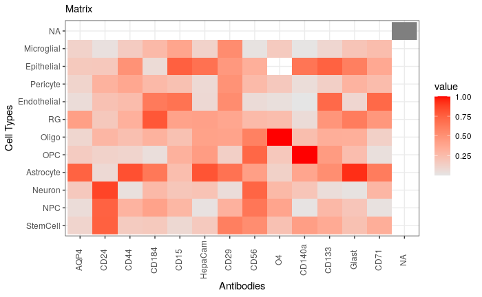

```r
ggplot(longData, aes(x = Var2, y = Var1)) +
  geom_raster(aes(fill=value)) +
  scale_fill_gradient(low="grey90", high="red") +
  labs(x="Antibodies", y="Cell Types", title="Matrix") +
  theme_bw() + theme(axis.text.x=element_text(size=9, angle=90, vjust=0.3),
                     axis.text.y=element_text(size=9),
                     plot.title=element_text(size=11))
dev.off()
```

See some of the other matrix of expression

```r
# keep the original matrix
# then plot each matrix with this script
# Ben Barres total seq
# A <- bb.norm
# HCL mean data
#A <- sc.pub
A<- fc.norm
# MBO inhouse scRNA seq
#A <- mbo.47.norm
#A <- mbo.160.norm
longData<-melt(A)
longData<-longData[longData$value!=0,]
ggplot(longData, aes(x = Var2, y = Var1)) +
  geom_raster(aes(fill=value)) +
  scale_fill_gradient(low="grey90", high="red") +
  labs(x="Antibodies", y="Cell Types", title="Matrix") +
  theme_bw() + theme(axis.text.x=element_text(size=9, angle=90, vjust=0.3),
                     axis.text.y=element_text(size=9),
                     plot.title=element_text(size=11))

png("ReferenceMatrix.png")
```

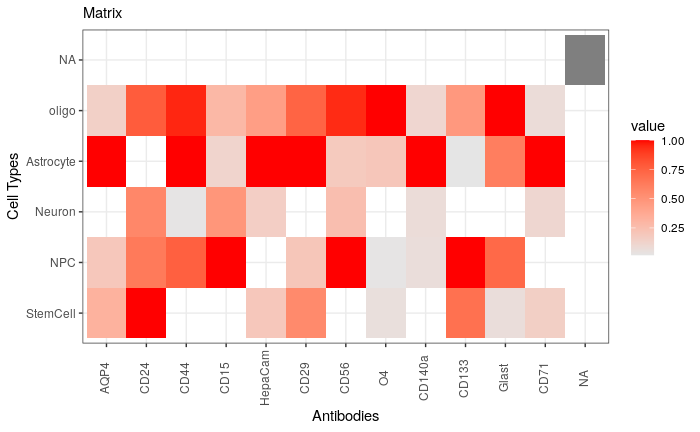

```r
ggplot(longData, aes(x = Var2, y = Var1)) +
  geom_raster(aes(fill=value)) +
  scale_fill_gradient(low="grey90", high="red") +
  labs(x="Antibodies", y="Cell Types", title="Matrix") +
  theme_bw() + theme(axis.text.x=element_text(size=9, angle=90, vjust=0.3),
                     axis.text.y=element_text(size=9),
                     plot.title=element_text(size=11))
dev.off()
```

[figure not shown]

```r
df.value <- fc[0:13,3:13]
new <- apply(df.value, MARGIN = 1, FUN = function(X) (X - min(X, na.rm=TRUE))/diff(range(X, na.rm=TRUE)))
head(new)
```

[output not shown]

Now I’ll take the mean values

```r
# we need to make an array
#  It takes rows(x), columns(y), and a number of matrices of dimensions nrow * ncol(z).

arr <- array(as.numeric(unlist(norm.list)), dim = c(13, 12, 5))


all.matrix <- abind(arr, along=3)
df.mean <- apply(all.matrix, c(1,2), mean,na.rm=TRUE)
head(df.mean)

# I have some values now - I need to check them against doing it individually in the matrices
aqp4 <- c(bb.norm[1,2],ucsc.norm[1,2],mbo.47.norm[1,2],mbo.160.norm[1,2],fc.norm[1,2])
mean.aqp4 = mean(na.omit(aqp4))
mean.aqp4

# yes it has worked but column 1 is the markers - which all turned into NaN

# add the column names back in
# get column names from an original matrix
col.names.df <- as.vector(colnames(bb))
colnames(df.mean) <- col.names.df
# remove the NaN column  "Marker"
mean.exp <- df.mean[,2:12]
# replace the antibody names
# get the marker names
markers <- as.vector(bb.norm['Marker'])
mean.exp<- cbind(markers,mean.exp)
head(mean.exp)
```

[output not shown]

I want to visualize the data I’ll need to make a ‘long table’

```r
boxplot(Expression~Marker, data=test.df, main= "scRNA")
```

```
no non-missing arguments to min; returning Infno non-missing arguments to max; returning -InfError in plot.window(xlim = xlim, ylim = ylim, log = log, yaxs = pars$yaxs) :
  need finite 'ylim' values
```

```r
print(colnames(fb3))
```

[output not shown]

```r
print(colnames(fb5))
```

[output not shown]

```r
# column names were not the same
fb5 <- fb5 %>% rename(Epithelial = Edpendymal.Epithealial)
# rbind worked to join two df but it doesn't add anything automatically to indicate where the data came from these are just turning into replicates
# add source column
fb5$Source <- "fb5"
head(fb5)
```

|  | Annotation | Marker | StemCell | NPC | Neuron | Astrocyte | OPC | Oligo | RG | Endothelial | Pericyte | Epithelial | Microglial | Neural.Crest | Source |
| --- | --- | --- | --- | --- | --- | --- | --- | --- | --- | --- | --- | --- | --- | --- | --- |
| 1 | AQP4 | AQP4 | 0.0000 | NA | 0.0000 | NA | NA | NA | 0.0107 | 0.0000 | NA | 0.0000 | 0.0000 | NA | fb5 |
| 2 | CD24 | CD24 | 3.3997 | NA | 5.0165 | NA | NA | NA | 3.1213 | 1.7726 | NA | 1.7081 | 2.2276 | NA | fb5 |
| 3 | CD44 | CD44 | 0.0178 | NA | 0.0040 | NA | NA | NA | 0.0110 | 0.0000 | NA | 0.0000 | 0.0000 | NA | fb5 |
| 4 | CXCR4 | CD184 | 0.2979 | NA | 0.2137 | NA | NA | NA | 0.3183 | 5.0667 | NA | 0.2875 | 0.7855 | NA | fb5 |
| 5 | Fut4/ssea1 | CD15 | 0.0172 | NA | 0.0125 | NA | NA | NA | 0.0207 | 0.0000 | NA | 0.0419 | 0.0000 | NA | fb5 |
| 6 | HepaCam | HepaCam | 0.0000 | NA | 0.0000 | NA | NA | NA | 0.0000 | 0.0000 | NA | 0.0000 | 0.0000 | NA | fb5 |

```r
fb3 <- fb3 %>% rename(Epithelial = Edpendymal)
# add source column for fb3
fb3$Source <- "fb3"
```

Z-score each matrix get a mean of 0 and std of 1

```r
tdf <- t(df)
tdf$z1 <- (tdf[1] - mean(tdf[1], na.rm = TRUE))/ sd(tdf[1], na.rm = TRUE)
```

```
Coercing LHS to a list
```

```r
zscorefun <- function(df) {
  new.df <-
  return(new.df)
}
df.scale2 <- (apply(rm.cat, 1, x - mean/sd))
```

```
Error in match.fun(FUN) : object 'x' not found
```

```r
twodf <- rbind(fb3,fb5)
head(twodf)

# perfect this works
# now I realize I need to z score first
```